# design_markdown

Timothy Oliver

2023-10-10

```r
options(scipen=999)

library(ggplot2)
library(viridis)
# call theme function
source("plotTheme_TO.R")
```

## R Markdown

Something about data and design choices

```r
pop_githubs <- read.csv("data/repositories.csv")
pop_githubs$Language[pop_githubs$Language==""]<-"No Language"
# table(pop_githubs$Language)

sort(table(pop_githubs$Language))
top_10_lang<-c("Python","JavaScript","No Language","Java","TypeScript","C++","Go","C","C#","PHP")
repos_in10Lang<-pop_githubs[pop_githubs$Language %in% top_10_lang,]
```

## Most Popular Primary Language

This plot aims to show the number of repositories out of the 215029 total that use the 10 most popular coding languages (among the data). I intend to use `Similarity` and filling the JavaScript and Python bars with a nearby annotation with the same color. Otherwise, I would truly like to set the width to deconflict certain x axis labels and show the full title and label the bars with the count of repositories over having a y-axis. I might be able to change the chart to a horizontal plot if needed.

[figure not shown]

```r
# plot of most common by language and
p <- ggplot(data = repos_in10Lang,
            mapping = aes(x=Language))+geom_bar()+
  labs(x="Primary Coding Language",
       y= "Repository Count",
       title = "Popular Github Repository Count by Primary Language",
       caption = "Source: Kaggle,\n10/1/2023 | Canard")+theme_test()

# display plot
p
```

## Rank Compared to Size

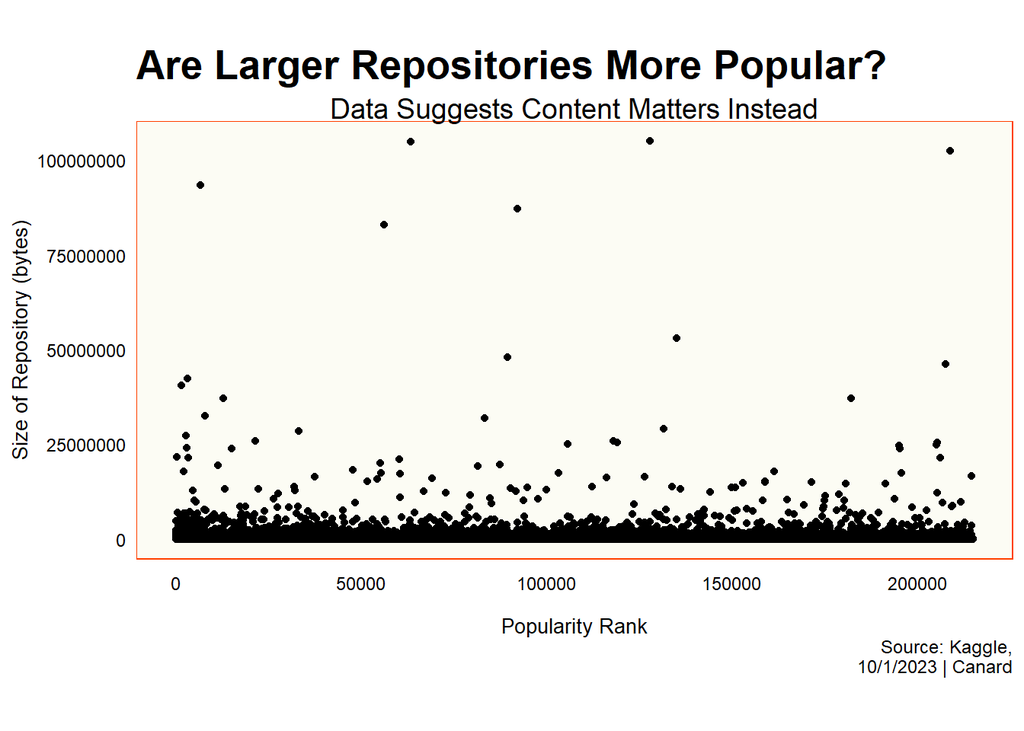

## Constantly Updated

This plot aims to show if popular Github repositories are updated frequently. The date for the last update is used, though I would love to include if a repository has no coding language or some other component. I am unsure of what plot would be best for this alongside the second dimension/property (hence the choice of scatter plot in the rough draft). I am also open to additional recommendations for the Gestalt principle to apply here.

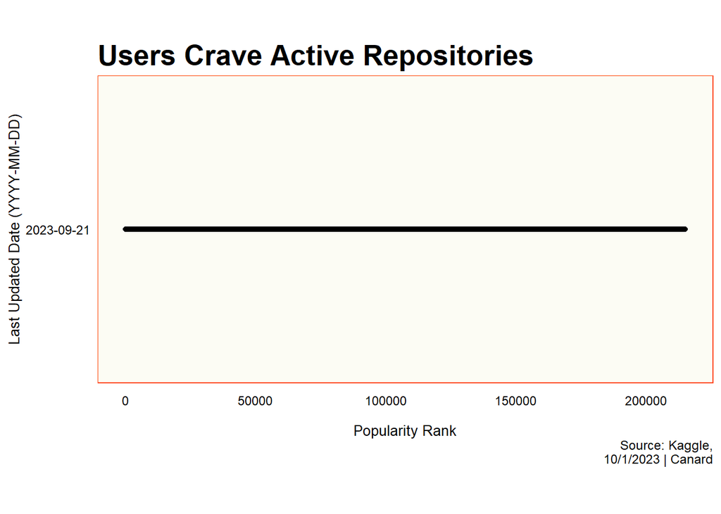